# Risk Factor Analysis

## Outcome Variable

**Outcome Variable:** ever_swasted

## Predictor Variables

**Intervention Variable:** birthwt

**Adjustment Set:**

- arm
- sex
- W_mage
- meducyrs
- feducyrs
- vagbrth
- single
- brthmon
- W_parity
- delta_W_mage
- delta_meducyrs
- delta_feducyrs
- delta_vagbrth
- delta_single
- delta_brthmon
- delta_W_parity

## Stratifying Variables

The analysis was stratified on these variable(s):

- agecat
- studyid
- country

## Data Summary

| agecat | studyid | country | birthwt | ever_swasted | n_cell | n |
| --- | --- | --- | --- | --- | --- | --- |
| 0-24 months (no birth wast) | CMC-V-BCS-2002 | INDIA | Normal or high birthweight | 0 | 271 | 361 |
| 0-24 months (no birth wast) | CMC-V-BCS-2002 | INDIA | Normal or high birthweight | 1 | 50 | 361 |
| 0-24 months (no birth wast) | CMC-V-BCS-2002 | INDIA | Low birthweight | 0 | 35 | 361 |
| 0-24 months (no birth wast) | CMC-V-BCS-2002 | INDIA | Low birthweight | 1 | 5 | 361 |
| 0-24 months (no birth wast) | CMIN | BANGLADESH | Normal or high birthweight | 0 | 12 | 17 |
| 0-24 months (no birth wast) | CMIN | BANGLADESH | Normal or high birthweight | 1 | 0 | 17 |
| 0-24 months (no birth wast) | CMIN | BANGLADESH | Low birthweight | 0 | 5 | 17 |
| 0-24 months (no birth wast) | CMIN | BANGLADESH | Low birthweight | 1 | 0 | 17 |
| 0-24 months (no birth wast) | COHORTS | GUATEMALA | Normal or high birthweight | 0 | 825 | 917 |
| 0-24 months (no birth wast) | COHORTS | GUATEMALA | Normal or high birthweight | 1 | 13 | 917 |
| 0-24 months (no birth wast) | COHORTS | GUATEMALA | Low birthweight | 0 | 74 | 917 |
| 0-24 months (no birth wast) | COHORTS | GUATEMALA | Low birthweight | 1 | 5 | 917 |
| 0-24 months (no birth wast) | COHORTS | INDIA | Normal or high birthweight | 0 | 5070 | 6524 |
| 0-24 months (no birth wast) | COHORTS | INDIA | Normal or high birthweight | 1 | 243 | 6524 |
| 0-24 months (no birth wast) | COHORTS | INDIA | Low birthweight | 0 | 1124 | 6524 |
| 0-24 months (no birth wast) | COHORTS | INDIA | Low birthweight | 1 | 87 | 6524 |
| 0-24 months (no birth wast) | COHORTS | PHILIPPINES | Normal or high birthweight | 0 | 2494 | 2975 |
| 0-24 months (no birth wast) | COHORTS | PHILIPPINES | Normal or high birthweight | 1 | 210 | 2975 |
| 0-24 months (no birth wast) | COHORTS | PHILIPPINES | Low birthweight | 0 | 233 | 2975 |
| 0-24 months (no birth wast) | COHORTS | PHILIPPINES | Low birthweight | 1 | 38 | 2975 |
| 0-24 months (no birth wast) | CONTENT | PERU | Normal or high birthweight | 0 | 2 | 2 |
| 0-24 months (no birth wast) | CONTENT | PERU | Normal or high birthweight | 1 | 0 | 2 |
| 0-24 months (no birth wast) | CONTENT | PERU | Low birthweight | 0 | 0 | 2 |
| 0-24 months (no birth wast) | CONTENT | PERU | Low birthweight | 1 | 0 | 2 |
| 0-24 months (no birth wast) | EE | PAKISTAN | Normal or high birthweight | 0 | 203 | 376 |
| 0-24 months (no birth wast) | EE | PAKISTAN | Normal or high birthweight | 1 | 40 | 376 |
| 0-24 months (no birth wast) | EE | PAKISTAN | Low birthweight | 0 | 107 | 376 |
| 0-24 months (no birth wast) | EE | PAKISTAN | Low birthweight | 1 | 26 | 376 |
| 0-24 months (no birth wast) | GMS-Nepal | NEPAL | Normal or high birthweight | 0 | 372 | 659 |
| 0-24 months (no birth wast) | GMS-Nepal | NEPAL | Normal or high birthweight | 1 | 86 | 659 |

[output cut: 78 more lines]

The following strata were considered:

- agecat: 0-24 months (no birth wast), studyid: CMC-V-BCS-2002, country: INDIA
- agecat: 0-24 months (no birth wast), studyid: CMIN, country: BANGLADESH
- agecat: 0-24 months (no birth wast), studyid: COHORTS, country: GUATEMALA
- agecat: 0-24 months (no birth wast), studyid: COHORTS, country: INDIA
- agecat: 0-24 months (no birth wast), studyid: COHORTS, country: PHILIPPINES
- agecat: 0-24 months (no birth wast), studyid: CONTENT, country: PERU
- agecat: 0-24 months (no birth wast), studyid: EE, country: PAKISTAN
- agecat: 0-24 months (no birth wast), studyid: GMS-Nepal, country: NEPAL
- agecat: 0-24 months (no birth wast), studyid: IRC, country: INDIA
- agecat: 0-24 months (no birth wast), studyid: JiVitA-3, country: BANGLADESH
- agecat: 0-24 months (no birth wast), studyid: JiVitA-4, country: BANGLADESH
- agecat: 0-24 months (no birth wast), studyid: Keneba, country: GAMBIA
- agecat: 0-24 months (no birth wast), studyid: MAL-ED, country: BANGLADESH
- agecat: 0-24 months (no birth wast), studyid: MAL-ED, country: BRAZIL
- agecat: 0-24 months (no birth wast), studyid: MAL-ED, country: INDIA
- agecat: 0-24 months (no birth wast), studyid: MAL-ED, country: NEPAL
- agecat: 0-24 months (no birth wast), studyid: MAL-ED, country: PERU
- agecat: 0-24 months (no birth wast), studyid: MAL-ED, country: SOUTH AFRICA
- agecat: 0-24 months (no birth wast), studyid: MAL-ED, country: TANZANIA, UNITED REPUBLIC OF
- agecat: 0-24 months (no birth wast), studyid: NIH-Birth, country: BANGLADESH
- agecat: 0-24 months (no birth wast), studyid: NIH-Crypto, country: BANGLADESH
- agecat: 0-24 months (no birth wast), studyid: PROBIT, country: BELARUS
- agecat: 0-24 months (no birth wast), studyid: PROVIDE, country: BANGLADESH
- agecat: 0-24 months (no birth wast), studyid: ResPak, country: PAKISTAN
- agecat: 0-24 months (no birth wast), studyid: SAS-CompFeed, country: INDIA
- agecat: 0-24 months (no birth wast), studyid: TanzaniaChild2, country: TANZANIA, UNITED REPUBLIC OF
- agecat: 0-24 months (no birth wast), studyid: ZVITAMBO, country: ZIMBABWE

### Dropped Strata

Some strata were dropped due to rare outcomes:

- agecat: 0-24 months (no birth wast), studyid: CMIN, country: BANGLADESH
- agecat: 0-24 months (no birth wast), studyid: CONTENT, country: PERU
- agecat: 0-24 months (no birth wast), studyid: MAL-ED, country: BANGLADESH
- agecat: 0-24 months (no birth wast), studyid: MAL-ED, country: BRAZIL
- agecat: 0-24 months (no birth wast), studyid: MAL-ED, country: INDIA
- agecat: 0-24 months (no birth wast), studyid: MAL-ED, country: NEPAL
- agecat: 0-24 months (no birth wast), studyid: MAL-ED, country: PERU
- agecat: 0-24 months (no birth wast), studyid: MAL-ED, country: SOUTH AFRICA
- agecat: 0-24 months (no birth wast), studyid: MAL-ED, country: TANZANIA, UNITED REPUBLIC OF
- agecat: 0-24 months (no birth wast), studyid: PROBIT, country: BELARUS
- agecat: 0-24 months (no birth wast), studyid: ResPak, country: PAKISTAN

## Methods Detail

We're interested in the causal parameters $E[Y_a]$ for all values of $a \in \mathcal{A}$. These parameters represent the mean outcome if, possibly contrary to fact, we intervened to set all units to have $A=a$. Under the randomization and positivity assumptions, these are identified by the statistical parameters $\psi_a=E_W[E_{Y|A,W}(Y|A=a,W)]$. In addition, we're interested in the mean of $Y$, $E[Y]$ under no intervention (the observed mean). We will estimate these parameters by using SuperLearner to fit the relevant likelihood factors -- $E_{Y|A,W}(Y|A=a,W)$ and $p(A=a|W)$, and then updating our likelihood fit using a joint TMLE.

For unadjusted analyses ($W=\{\}$), initial likelihoods were estimated using Lrnr_glm to estimate the simple $E(Y|A)$ and Lrnr_mean to estimate $p(A)$. For adjusted analyses, a small library containing Lrnr_glmnet, Lrnr_xgboost, and Lrnr_mean was used.

Having estimated these parameters, we will then use the delta method to estimate relative risks and attributable risks relative to a prespecified baseline level of $A$.

# Results Detail

## Results Plots

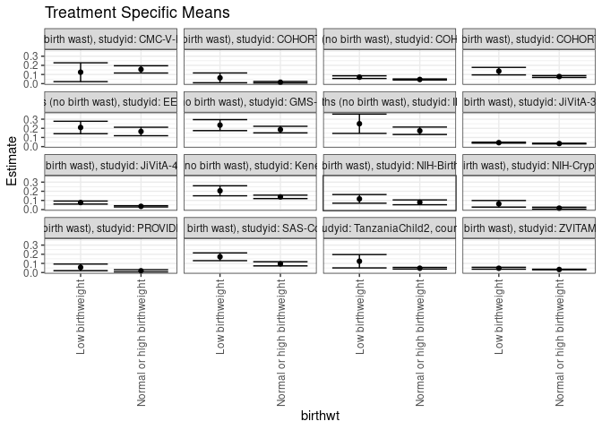

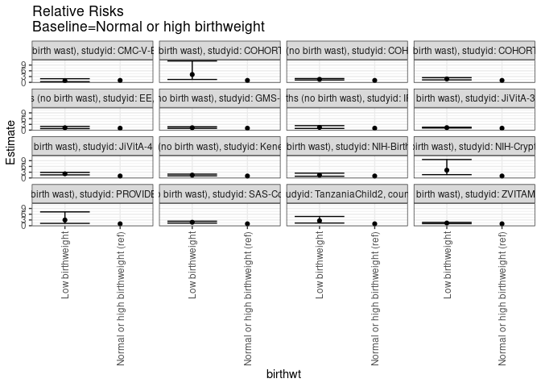

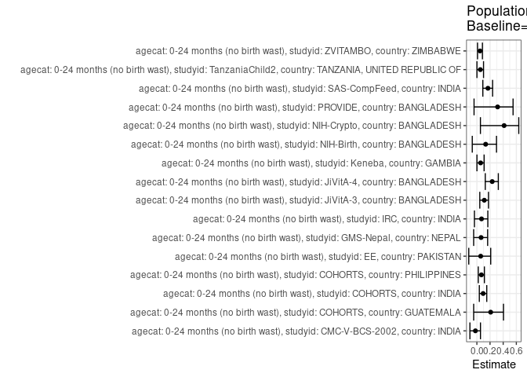

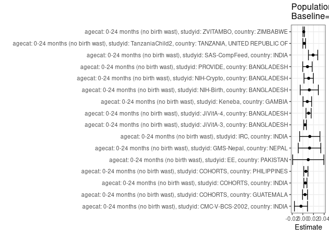

## Results Table

### Parameter: TSM

| agecat | studyid | country | intervention_level | baseline_level | estimate | ci_lower | ci_upper |
| --- | --- | --- | --- | --- | --- | --- | --- |
| 0-24 months (no birth wast) | CMC-V-BCS-2002 | INDIA | Normal or high birthweight | NA | 0.1557632 | 0.1160384 | 0.1954881 |
| 0-24 months (no birth wast) | CMC-V-BCS-2002 | INDIA | Low birthweight | NA | 0.1250000 | 0.0223688 | 0.2276312 |
| 0-24 months (no birth wast) | COHORTS | GUATEMALA | Normal or high birthweight | NA | 0.0155131 | 0.0071413 | 0.0238849 |
| 0-24 months (no birth wast) | COHORTS | GUATEMALA | Low birthweight | NA | 0.0632911 | 0.0095700 | 0.1170123 |
| 0-24 months (no birth wast) | COHORTS | INDIA | Normal or high birthweight | NA | 0.0457576 | 0.0401474 | 0.0513677 |
| 0-24 months (no birth wast) | COHORTS | INDIA | Low birthweight | NA | 0.0708968 | 0.0560057 | 0.0857878 |
| 0-24 months (no birth wast) | COHORTS | PHILIPPINES | Normal or high birthweight | NA | 0.0776216 | 0.0675371 | 0.0877061 |
| 0-24 months (no birth wast) | COHORTS | PHILIPPINES | Low birthweight | NA | 0.1365110 | 0.0956194 | 0.1774026 |
| 0-24 months (no birth wast) | EE | PAKISTAN | Normal or high birthweight | NA | 0.1653462 | 0.1188998 | 0.2117927 |
| 0-24 months (no birth wast) | EE | PAKISTAN | Low birthweight | NA | 0.2090307 | 0.1411920 | 0.2768694 |
| 0-24 months (no birth wast) | GMS-Nepal | NEPAL | Normal or high birthweight | NA | 0.1861609 | 0.1500934 | 0.2222283 |
| 0-24 months (no birth wast) | GMS-Nepal | NEPAL | Low birthweight | NA | 0.2348937 | 0.1748004 | 0.2949869 |
| 0-24 months (no birth wast) | IRC | INDIA | Normal or high birthweight | NA | 0.1730235 | 0.1324062 | 0.2136408 |
| 0-24 months (no birth wast) | IRC | INDIA | Low birthweight | NA | 0.2499538 | 0.1446870 | 0.3552206 |
| 0-24 months (no birth wast) | JiVitA-3 | BANGLADESH | Normal or high birthweight | NA | 0.0333718 | 0.0297830 | 0.0369606 |
| 0-24 months (no birth wast) | JiVitA-3 | BANGLADESH | Low birthweight | NA | 0.0433732 | 0.0384438 | 0.0483027 |
| 0-24 months (no birth wast) | JiVitA-4 | BANGLADESH | Normal or high birthweight | NA | 0.0355447 | 0.0286584 | 0.0424310 |
| 0-24 months (no birth wast) | JiVitA-4 | BANGLADESH | Low birthweight | NA | 0.0766882 | 0.0600915 | 0.0932849 |
| 0-24 months (no birth wast) | Keneba | GAMBIA | Normal or high birthweight | NA | 0.1389941 | 0.1202263 | 0.1577620 |
| 0-24 months (no birth wast) | Keneba | GAMBIA | Low birthweight | NA | 0.2054185 | 0.1504436 | 0.2603934 |
| 0-24 months (no birth wast) | NIH-Birth | BANGLADESH | Normal or high birthweight | NA | 0.0790359 | 0.0527331 | 0.1053387 |
| 0-24 months (no birth wast) | NIH-Birth | BANGLADESH | Low birthweight | NA | 0.1170714 | 0.0697615 | 0.1643813 |
| 0-24 months (no birth wast) | NIH-Crypto | BANGLADESH | Normal or high birthweight | NA | 0.0155440 | 0.0054613 | 0.0256267 |
| 0-24 months (no birth wast) | NIH-Crypto | BANGLADESH | Low birthweight | NA | 0.0628571 | 0.0268741 | 0.0988402 |
| 0-24 months (no birth wast) | PROVIDE | BANGLADESH | Normal or high birthweight | NA | 0.0189394 | 0.0073041 | 0.0305747 |
| 0-24 months (no birth wast) | PROVIDE | BANGLADESH | Low birthweight | NA | 0.0566038 | 0.0206590 | 0.0925485 |
| 0-24 months (no birth wast) | SAS-CompFeed | INDIA | Normal or high birthweight | NA | 0.0953483 | 0.0729147 | 0.1177820 |
| 0-24 months (no birth wast) | SAS-CompFeed | INDIA | Low birthweight | NA | 0.1723192 | 0.1300045 | 0.2146340 |
| 0-24 months (no birth wast) | TanzaniaChild2 | TANZANIA, UNITED REPUBLIC OF | Normal or high birthweight | NA | 0.0474002 | 0.0386717 | 0.0561287 |
| 0-24 months (no birth wast) | TanzaniaChild2 | TANZANIA, UNITED REPUBLIC OF | Low birthweight | NA | 0.1235824 | 0.0506081 | 0.1965566 |
| 0-24 months (no birth wast) | ZVITAMBO | ZIMBABWE | Normal or high birthweight | NA | 0.0334121 | 0.0301855 | 0.0366386 |
| 0-24 months (no birth wast) | ZVITAMBO | ZIMBABWE | Low birthweight | NA | 0.0469032 | 0.0367451 | 0.0570613 |

### Parameter: E(Y)

| agecat | studyid | country | intervention_level | baseline_level | estimate | ci_lower | ci_upper |
| --- | --- | --- | --- | --- | --- | --- | --- |
| 0-24 months (no birth wast) | CMC-V-BCS-2002 | INDIA | NA | NA | 0.1523546 | 0.1152325 | 0.1894766 |
| 0-24 months (no birth wast) | COHORTS | GUATEMALA | NA | NA | 0.0196292 | 0.0106457 | 0.0286128 |
| 0-24 months (no birth wast) | COHORTS | INDIA | NA | NA | 0.0505825 | 0.0452644 | 0.0559005 |
| 0-24 months (no birth wast) | COHORTS | PHILIPPINES | NA | NA | 0.0833613 | 0.0734265 | 0.0932961 |
| 0-24 months (no birth wast) | EE | PAKISTAN | NA | NA | 0.1755319 | 0.1370287 | 0.2140352 |
| 0-24 months (no birth wast) | GMS-Nepal | NEPAL | NA | NA | 0.1987860 | 0.1682929 | 0.2292792 |
| 0-24 months (no birth wast) | IRC | INDIA | NA | NA | 0.1861042 | 0.1480592 | 0.2241492 |
| 0-24 months (no birth wast) | JiVitA-3 | BANGLADESH | NA | NA | 0.0376119 | 0.0347245 | 0.0404993 |
| 0-24 months (no birth wast) | JiVitA-4 | BANGLADESH | NA | NA | 0.0463561 | 0.0396916 | 0.0530207 |
| 0-24 months (no birth wast) | Keneba | GAMBIA | NA | NA | 0.1474234 | 0.1296705 | 0.1651762 |
| 0-24 months (no birth wast) | NIH-Birth | BANGLADESH | NA | NA | 0.0912220 | 0.0677898 | 0.1146542 |
| 0-24 months (no birth wast) | NIH-Crypto | BANGLADESH | NA | NA | 0.0265252 | 0.0150478 | 0.0380026 |
| 0-24 months (no birth wast) | PROVIDE | BANGLADESH | NA | NA | 0.0276565 | 0.0153851 | 0.0399279 |
| 0-24 months (no birth wast) | SAS-CompFeed | INDIA | NA | NA | 0.1146113 | 0.0915227 | 0.1376999 |
| 0-24 months (no birth wast) | TanzaniaChild2 | TANZANIA, UNITED REPUBLIC OF | NA | NA | 0.0500212 | 0.0412227 | 0.0588197 |
| 0-24 months (no birth wast) | ZVITAMBO | ZIMBABWE | NA | NA | 0.0350916 | 0.0319981 | 0.0381851 |

### Parameter: RR

| agecat | studyid | country | intervention_level | baseline_level | estimate | ci_lower | ci_upper |
| --- | --- | --- | --- | --- | --- | --- | --- |
| 0-24 months (no birth wast) | CMC-V-BCS-2002 | INDIA | Normal or high birthweight | Normal or high birthweight | 1.000000 | 1.0000000 | 1.000000 |
| 0-24 months (no birth wast) | CMC-V-BCS-2002 | INDIA | Low birthweight | Normal or high birthweight | 0.802500 | 0.3396735 | 1.895957 |
| 0-24 months (no birth wast) | COHORTS | GUATEMALA | Normal or high birthweight | Normal or high birthweight | 1.000000 | 1.0000000 | 1.000000 |
| 0-24 months (no birth wast) | COHORTS | GUATEMALA | Low birthweight | Normal or high birthweight | 4.079844 | 1.4921752 | 11.154943 |
| 0-24 months (no birth wast) | COHORTS | INDIA | Normal or high birthweight | Normal or high birthweight | 1.000000 | 1.0000000 | 1.000000 |
| 0-24 months (no birth wast) | COHORTS | INDIA | Low birthweight | Normal or high birthweight | 1.549400 | 1.2152952 | 1.975356 |
| 0-24 months (no birth wast) | COHORTS | PHILIPPINES | Normal or high birthweight | Normal or high birthweight | 1.000000 | 1.0000000 | 1.000000 |
| 0-24 months (no birth wast) | COHORTS | PHILIPPINES | Low birthweight | Normal or high birthweight | 1.758672 | 1.2689874 | 2.437319 |
| 0-24 months (no birth wast) | EE | PAKISTAN | Normal or high birthweight | Normal or high birthweight | 1.000000 | 1.0000000 | 1.000000 |
| 0-24 months (no birth wast) | EE | PAKISTAN | Low birthweight | Normal or high birthweight | 1.264200 | 0.8211926 | 1.946197 |
| 0-24 months (no birth wast) | GMS-Nepal | NEPAL | Normal or high birthweight | Normal or high birthweight | 1.000000 | 1.0000000 | 1.000000 |
| 0-24 months (no birth wast) | GMS-Nepal | NEPAL | Low birthweight | Normal or high birthweight | 1.261778 | 0.9160562 | 1.737976 |
| 0-24 months (no birth wast) | IRC | INDIA | Normal or high birthweight | Normal or high birthweight | 1.000000 | 1.0000000 | 1.000000 |
| 0-24 months (no birth wast) | IRC | INDIA | Low birthweight | Normal or high birthweight | 1.444623 | 0.8914524 | 2.341052 |
| 0-24 months (no birth wast) | JiVitA-3 | BANGLADESH | Normal or high birthweight | Normal or high birthweight | 1.000000 | 1.0000000 | 1.000000 |
| 0-24 months (no birth wast) | JiVitA-3 | BANGLADESH | Low birthweight | Normal or high birthweight | 1.299697 | 1.1133035 | 1.517298 |
| 0-24 months (no birth wast) | JiVitA-4 | BANGLADESH | Normal or high birthweight | Normal or high birthweight | 1.000000 | 1.0000000 | 1.000000 |
| 0-24 months (no birth wast) | JiVitA-4 | BANGLADESH | Low birthweight | Normal or high birthweight | 2.157516 | 1.6058960 | 2.898615 |
| 0-24 months (no birth wast) | Keneba | GAMBIA | Normal or high birthweight | Normal or high birthweight | 1.000000 | 1.0000000 | 1.000000 |
| 0-24 months (no birth wast) | Keneba | GAMBIA | Low birthweight | Normal or high birthweight | 1.477893 | 1.0954944 | 1.993775 |
| 0-24 months (no birth wast) | NIH-Birth | BANGLADESH | Normal or high birthweight | Normal or high birthweight | 1.000000 | 1.0000000 | 1.000000 |
| 0-24 months (no birth wast) | NIH-Birth | BANGLADESH | Low birthweight | Normal or high birthweight | 1.481243 | 0.8789385 | 2.496285 |
| 0-24 months (no birth wast) | NIH-Crypto | BANGLADESH | Normal or high birthweight | Normal or high birthweight | 1.000000 | 1.0000000 | 1.000000 |
| 0-24 months (no birth wast) | NIH-Crypto | BANGLADESH | Low birthweight | Normal or high birthweight | 4.043810 | 1.7024219 | 9.605372 |
| 0-24 months (no birth wast) | PROVIDE | BANGLADESH | Normal or high birthweight | Normal or high birthweight | 1.000000 | 1.0000000 | 1.000000 |
| 0-24 months (no birth wast) | PROVIDE | BANGLADESH | Low birthweight | Normal or high birthweight | 2.988679 | 1.2352498 | 7.231091 |
| 0-24 months (no birth wast) | SAS-CompFeed | INDIA | Normal or high birthweight | Normal or high birthweight | 1.000000 | 1.0000000 | 1.000000 |
| 0-24 months (no birth wast) | SAS-CompFeed | INDIA | Low birthweight | Normal or high birthweight | 1.807260 | 1.3895501 | 2.350537 |
| 0-24 months (no birth wast) | TanzaniaChild2 | TANZANIA, UNITED REPUBLIC OF | Normal or high birthweight | Normal or high birthweight | 1.000000 | 1.0000000 | 1.000000 |
| 0-24 months (no birth wast) | TanzaniaChild2 | TANZANIA, UNITED REPUBLIC OF | Low birthweight | Normal or high birthweight | 2.607210 | 1.4046178 | 4.839427 |
| 0-24 months (no birth wast) | ZVITAMBO | ZIMBABWE | Normal or high birthweight | Normal or high birthweight | 1.000000 | 1.0000000 | 1.000000 |
| 0-24 months (no birth wast) | ZVITAMBO | ZIMBABWE | Low birthweight | Normal or high birthweight | 1.403779 | 1.1074602 | 1.779384 |

### Parameter: PAR

| agecat | studyid | country | intervention_level | baseline_level | estimate | ci_lower | ci_upper |
| --- | --- | --- | --- | --- | --- | --- | --- |
| 0-24 months (no birth wast) | CMC-V-BCS-2002 | INDIA | Normal or high birthweight | NA | -0.0034087 | -0.0156434 | 0.0088261 |
| 0-24 months (no birth wast) | COHORTS | GUATEMALA | Normal or high birthweight | NA | 0.0041161 | -0.0006476 | 0.0088798 |
| 0-24 months (no birth wast) | COHORTS | INDIA | Normal or high birthweight | NA | 0.0048249 | 0.0019258 | 0.0077240 |
| 0-24 months (no birth wast) | COHORTS | PHILIPPINES | Normal or high birthweight | NA | 0.0057397 | 0.0018175 | 0.0096619 |
| 0-24 months (no birth wast) | EE | PAKISTAN | Normal or high birthweight | NA | 0.0101857 | -0.0190632 | 0.0394346 |
| 0-24 months (no birth wast) | GMS-Nepal | NEPAL | Normal or high birthweight | NA | 0.0126252 | -0.0084840 | 0.0337343 |
| 0-24 months (no birth wast) | IRC | INDIA | Normal or high birthweight | NA | 0.0130807 | -0.0059491 | 0.0321105 |
| 0-24 months (no birth wast) | JiVitA-3 | BANGLADESH | Normal or high birthweight | NA | 0.0042401 | 0.0017431 | 0.0067371 |
| 0-24 months (no birth wast) | JiVitA-4 | BANGLADESH | Normal or high birthweight | NA | 0.0108115 | 0.0059737 | 0.0156492 |
| 0-24 months (no birth wast) | Keneba | GAMBIA | Normal or high birthweight | NA | 0.0084292 | 0.0003528 | 0.0165056 |
| 0-24 months (no birth wast) | NIH-Birth | BANGLADESH | Normal or high birthweight | NA | 0.0121861 | -0.0047906 | 0.0291629 |
| 0-24 months (no birth wast) | NIH-Crypto | BANGLADESH | Normal or high birthweight | NA | 0.0109812 | 0.0021914 | 0.0197709 |
| 0-24 months (no birth wast) | PROVIDE | BANGLADESH | Normal or high birthweight | NA | 0.0087171 | -0.0001074 | 0.0175416 |
| 0-24 months (no birth wast) | SAS-CompFeed | INDIA | Normal or high birthweight | NA | 0.0192629 | 0.0105835 | 0.0279423 |
| 0-24 months (no birth wast) | TanzaniaChild2 | TANZANIA, UNITED REPUBLIC OF | Normal or high birthweight | NA | 0.0026210 | 0.0000810 | 0.0051609 |
| 0-24 months (no birth wast) | ZVITAMBO | ZIMBABWE | Normal or high birthweight | NA | 0.0016795 | 0.0003651 | 0.0029940 |

### Parameter: PAF

| agecat | studyid | country | intervention_level | baseline_level | estimate | ci_lower | ci_upper |
| --- | --- | --- | --- | --- | --- | --- | --- |
| 0-24 months (no birth wast) | CMC-V-BCS-2002 | INDIA | Normal or high birthweight | NA | -0.0223733 | -0.1057891 | 0.0547501 |
| 0-24 months (no birth wast) | COHORTS | GUATEMALA | Normal or high birthweight | NA | 0.2096924 | -0.0486896 | 0.4044128 |
| 0-24 months (no birth wast) | COHORTS | INDIA | Normal or high birthweight | NA | 0.0953869 | 0.0370957 | 0.1501493 |
| 0-24 months (no birth wast) | COHORTS | PHILIPPINES | Normal or high birthweight | NA | 0.0688534 | 0.0212165 | 0.1141718 |
| 0-24 months (no birth wast) | EE | PAKISTAN | Normal or high birthweight | NA | 0.0580276 | -0.1236099 | 0.2103024 |
| 0-24 months (no birth wast) | GMS-Nepal | NEPAL | Normal or high birthweight | NA | 0.0635113 | -0.0488021 | 0.1637975 |
| 0-24 months (no birth wast) | IRC | INDIA | Normal or high birthweight | NA | 0.0702871 | -0.0371569 | 0.1666004 |
| 0-24 months (no birth wast) | JiVitA-3 | BANGLADESH | Normal or high birthweight | NA | 0.1127333 | 0.0442864 | 0.1762781 |
| 0-24 months (no birth wast) | JiVitA-4 | BANGLADESH | Normal or high birthweight | NA | 0.2332264 | 0.1275484 | 0.3261039 |
| 0-24 months (no birth wast) | Keneba | GAMBIA | Normal or high birthweight | NA | 0.0571770 | 0.0010291 | 0.1101691 |
| 0-24 months (no birth wast) | NIH-Birth | BANGLADESH | Normal or high birthweight | NA | 0.1335877 | -0.0701347 | 0.2985274 |
| 0-24 months (no birth wast) | NIH-Crypto | BANGLADESH | Normal or high birthweight | NA | 0.4139896 | 0.0540478 | 0.6369709 |
| 0-24 months (no birth wast) | PROVIDE | BANGLADESH | Normal or high birthweight | NA | 0.3151914 | -0.0430123 | 0.5503765 |
| 0-24 months (no birth wast) | SAS-CompFeed | INDIA | Normal or high birthweight | NA | 0.1680718 | 0.0902394 | 0.2392454 |
| 0-24 months (no birth wast) | TanzaniaChild2 | TANZANIA, UNITED REPUBLIC OF | Normal or high birthweight | NA | 0.0523971 | 0.0010280 | 0.1011248 |
| 0-24 months (no birth wast) | ZVITAMBO | ZIMBABWE | Normal or high birthweight | NA | 0.0478608 | 0.0098886 | 0.0843767 |